# Homework #7: Trees and Forests

Siyu Jian / sj9va

Due: Mon Apr 12 | 10:55am

**SYS 4582/6018 | Spring 2021 | University of Virginia**

# Required R packages and Directories

```r
data.dir = 'https://mdporter.github.io/SYS6018/data/' # data directory
library(R6018)     # functions for SYS-6018
library(tidyverse) # functions for data manipulation
library(randomForest)
```

# Problem 1: Tree Splitting for classification

Consider the Gini index, classification error, and entropy impurity measures in a simple classification setting with two classes.

Create a single plot that displays each of these quantities as a function of $p_m$, the estimated probability of an observation in node $m$ being from class 1. The x-axis should display $p_m$, ranging from 0 to 1, and the y-axis should display the value of the Gini index, classification error, and entropy.

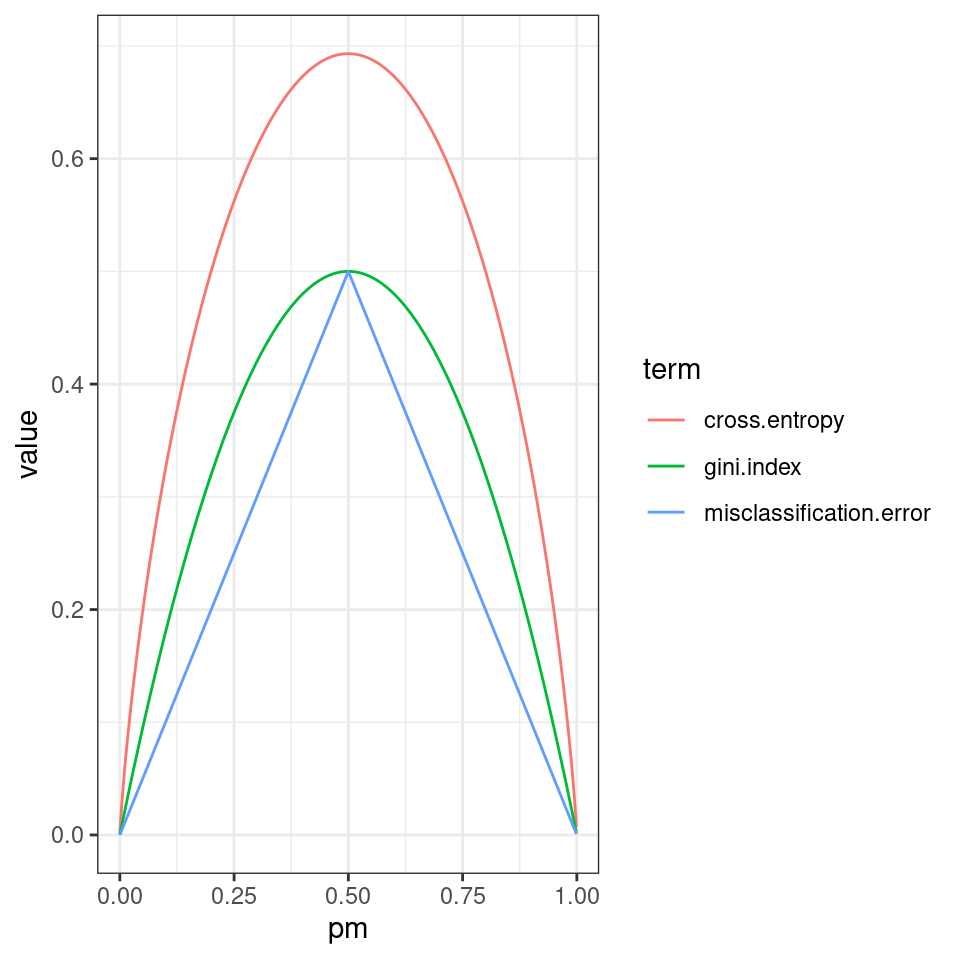

```r
pm <- seq(0.0001,1,0.001)  #
misclassification.error <- 1 - pmax(pm, 1-pm)
gini.index     <- 2*pm*(1-pm)
cross.entropy  <- - (pm * log(pm)  + (1-pm)*log(1-pm))

res.1 = tibble(pm = pm, term = "misclassification.error", value = misclassification.error)
res.1 = bind_rows(res.1,tibble(pm =pm, term = "gini.index",value = gini.index))
res.1 = bind_rows(res.1, tibble(pm = pm, term = "cross.entropy", value = cross.entropy))


ggplot(res.1, aes(x =  pm, y = value, color=term))  + geom_line()
```

# Problem 2: Combining bootstrap estimates

Suppose we produce ten bootstrapped samples from a data set containing red and green classes. We then apply a classification tree to each bootstrapped sample and, for a specific value of $X$, produce the following 10 estimates of $\Pr(\text{Class is Red} \mid X)$: $\{0.2, 0.25, 0.3, 0.4, 0.4, 0.45, 0.7, 0.85, 0.9, 0.9\}$.

## a. ISLR 8.2 describes the *majority vote* approach for making a hard classification from a set of bagged classifiers. What is the final classification for this example using majority voting?

```r
res.2a = ifelse(sum(p_red > 0.5)/length(p_red)>0.5, "Red","Green")
res.2a
```

```
#> [1] "Green"
```

With the *majority vote* approach, the final classification for this example would be Green

## b. An alternative is to base the final classification on the average probability. What is the final classification for this example using average probability?

```r
average_prob = mean(p_red)
res.2b = ifelse(mean(p_red) >= 0.5, "Red", "Green" )
```

With the average probability approach. The average value is 0.535, the final classification for this example with average probability is Red

## c. Suppose the cost of mis-classifying a Red observation (as Green) is twice as costly as mis-classifying a Green observation (as Red). How would you modify both approaches to make better final classifications under these unequal costs? Report the final classifications.

Since mis-classify cost are different for the two observation. The threshold will adjust to match the cost for each observation $\frac{2}{3}$.

```r
res.2c.1 = ifelse(mean(p_red) >= 2/3.0, "Red","Green")
res.2c.2 = ifelse(sum(p_red > 0.5)/length(p_red)>2/3.0, "red","green")
```

The final classification for the example is Green

# Problem 3: Random Forest Tuning

Random forest has several tuning parameters that you will explore in this problem. We will use the `Boston` housing data from the `MASS` R package (See the ISLR Lab in section 8.3.3 for example code).

- Note: remember that `MASS` can mask the `dplyr::select()` function.

## b. Use a random forest model to predict `medv`, the median value of owner-occupied homes (in $1000s). Use the default parameters and report the 10-fold cross-validation MSE.

```r
set.seed(200)
# prepare the training dataset
trainX.3b  = MASS::Boston %>% select(-medv)
trainY.3b  = MASS::Boston %>% select(medv)

randf.boston.cv = rfcv(trainx = as.matrix(trainX.3b), trainy = as.matrix(trainY.3b), cv.fold=10)
res.3b = randf.boston.cv$error.cv %>% as.matrix()

colnames(res.3b) <- c("MSE")
res.3b %>% knitr::kable()
```

|  | MSE |
| --- | --- |
| 13 | 10.65 |
| 6 | 10.36 |
| 3 | 14.43 |
| 1 | 46.10 |

**Notes**, the first column is the mtry, the second colomn is the MSE.

## c. Now we will vary the tuning parameters of `mtry` and `ntree` to see what effect they have on performance.

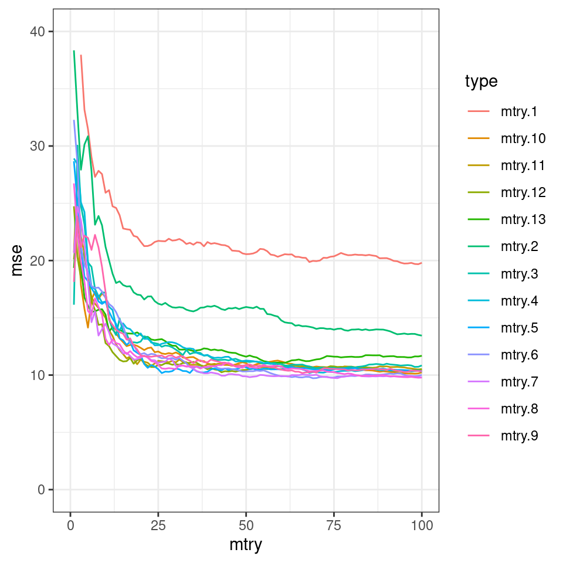

```r
set.seed(1234)
N.repeat = 5
mtry.Max = 13
ntree.Max = 200

res.3c = tibble(type=str_c(),mtry= numeric(),mse = numeric())
for ( mtry.step in seq(1:mtry.Max)){
  ntry.step.mse = vector(length = ntree.Max)
  for(step in 1:N.repeat){
    rf.step = randomForest(medv ~., data = MASS::Boston, mtry = mtry.step, ntree = ntree.Max)
    ntry.step.mse = ntry.step.mse + rf.step$mse
  }
  # # calculate the mean of the mse
  ntry.step.mse = ntry.step.mse / N.repeat
  res.3c = bind_rows(res.3c, tibble(mtry = 1:ntree.Max,type = sprintf('mtry.%d',mtry.step), mse = rf.step$mse))
}

res.3c %>% ggplot(aes(x= mtry, y = mse, color = type)) + geom_line() + ylim(0,40)  + xlim(0,100)
```